# Financial Contributions to Presidential Campaigns by State

### By Ruchita Maheshwary

In this report, I analyzed the data set for around 1304500 contributions for presidential elections from the state of California.

**Brief description about the dataset variables:**

- COMMITTEE ID- A 9-character alpha-numeric code assigned to a committee by the Federal Election Commission.
- CANDIDATE ID - A 9-character alpha-numeric code assigned to a candidate by the Federal Election Commission.
- CANDIDATE NAME
- CONTRIBUTOR NAME - Reported name of the contributor.
- CONTRIBUTOR CITY - Reported city of the contributor.
- CONTRIBUTOR STATE - Reported state of the contributor.
- CONTRIBUTOR ZIP CODE - Reported zip code of the contributor.
- CONTRIBUTOR EMPLOYER - Reported employer of the contributor.
- CONTRIBUTOR OCCUPATION - Reported occupation of the contributor.
- CONTRIBUTION RECEIPT AMOUNT - Reported contribution amount.
- CONTRIBUTION RECEIPT DATE - Reported contribution receipt date.  
  The date format is DD-MMM-YYYY.
- RECEIPT DESCRIPTION - Additional information reported by the committee about a specific contribution.
- MEMO CODE - ‘X’ indicates the reporting committee has provided additional text to describe a specific contribution. See the MEMO TEXT.
- MEMO TEXT - Additional information reported by the committee about a specific contribution.
- FORM TYPE - Indicates what schedule and line number the reporting committee reported a specific transaction.
  - SA17A: Form 3P Schedule A Line 17A
  - SA18: Form 3P Schedule A Line 18
  - SB28A: Form 3P Schedule B Line 28A
- FILE NUMBER - A unique number assigned to a report and all its associated transactions.
- TRANSACTION ID - A unique identifier permanently associated with each itemization or transaction appearing in an FEC electronic file.
- ELECTION TYPE / PRIMARY-GENERAL INDICATOR - This code indicates the election for which the contribution was made. EYYYY (election plus election year)
  - P = Primary
  - G = General
  - O = Other
  - C = Convention
  - R = Runoff
  - S = Special
  - E = Recount

# Univariate Plots Section

```
## [1] 1304346      18
```

```
## 'data.frame':    1304346 obs. of  18 variables:
##  $ cmte_id          : chr  "C00575795" "C00575795" "C00575795" "C00580100" ...
##  $ cand_id          : Factor w/ 25 levels "P00003392","P20002671",..: 1 1 1 23 12 23 12 12 12 1 ...
##  $ cand_nm          : Factor w/ 25 levels "Bush, Jeb","Carson, Benjamin S.",..: 4 4 4 23 20 23 20 20 20 4 ...
##  $ contbr_nm        : Factor w/ 231294 levels "'CALL, BARBARA",..: 7753 31629 70312 175051 117924 176417 119377 119377 119411 92354 ...
##  $ contbr_city      : Factor w/ 2532 levels "-4086","#NAME?",..: 1135 323 728 1182 322 1911 1808 1808 2400 1093 ...
##  $ contbr_st        : Factor w/ 1 level "CA": 1 1 1 1 1 1 1 1 1 1 ...
##  $ contbr_zip       : Factor w/ 143655 levels "00000","000090272",..: 115154 71794 53863 126926 66454 139487 17326 17326 45923 58803 ...
##  $ contbr_employer  : Factor w/ 65599 levels "''RETIRED''",..: NA NA NA 27607 4490 27607 62115 62115 41405 NA ...
##  $ contbr_occupation: Factor w/ 28621 levels "''RETIRED''",..: 21475 21475 21475 12736 23941 12736 17979 17979 19678 21475 ...
##  $ contb_receipt_amt: num  50 200 5 48.3 40 ...
##  $ contb_receipt_dt : Factor w/ 732 levels "01-APR-15","01-APR-16",..: 596 446 27 486 85 564 108 132 85 446 ...
##  $ receipt_desc     : Factor w/ 73 levels "* EARMARKED CONTRIBUTION: SEE BELOW REATTRIBUTION/REFUND PENDING",..: NA NA NA NA NA NA NA NA NA NA ...
##  $ memo_cd          : Factor w/ 1 level "X": 1 1 1 1 NA 1 NA NA NA 1 ...
##  $ memo_text        : Factor w/ 427 levels "$0.02 REFUNDED ON 10/21/2016",..: 125 125 125 NA 89 NA 89 89 89 125 ...
##  $ form_tp          : Factor w/ 3 levels "SA17A","SA18",..: 2 2 2 2 1 2 1 1 1 2 ...
##  $ file_num         : int  1091718 1091718 1091718 1146165 1077404 1146165 1077404 1077404 1077404 1091718 ...
##  $ tran_id          : Factor w/ 1300659 levels "A000771210424405B8CF",..: 466737 466019 463401 852428 1037145 890506 1038589 1040890 1036607 466057 ...
##  $ election_tp      : Factor w/ 4 levels "G2016","O2016",..: 3 3 3 1 3 1 3 3 3 3 ...
```

```
##    cmte_id               cand_id                            cand_nm
##  Length:1304346     P00003392:688524   Clinton, Hillary Rodham  :688524
##  Class :character   P60007168:407164   Sanders, Bernard         :407164
##  Mode  :character   P80001571: 86258   Trump, Donald J.         : 86258
##                     P60006111: 57822   Cruz, Rafael Edward 'Ted': 57822
##                     P60005915: 27370   Carson, Benjamin S.      : 27370
##                     P60006723: 14095   Rubio, Marco             : 14095
##                     (Other)  : 23113   (Other)                  : 23113
##             contbr_nm              contbr_city      contbr_st
##  PETIT, MICHAEL  :    473   LOS ANGELES  : 102710   CA:1304346
##  MITCHELL, MARCIA:    409   SAN FRANCISCO:  90937
##  SMITH, CHERYL   :    375   SAN DIEGO    :  46129
##  SAMATUA, DENISE :    373   OAKLAND      :  33235
##  CARROLL, TERI   :    352   SAN JOSE     :  30674
##  ADAM, MONIQUE   :    321   (Other)      :1000626
##  (Other)         :1302043   NA's         :     35
##    contbr_zip           contbr_employer               contbr_occupation
##  92660  :    660   RETIRED      :121569   RETIRED              :260546
##  92037  :    565   SELF-EMPLOYED:120187   NOT EMPLOYED         :115598
##  90049  :    495   NONE         : 84297   ATTORNEY             : 36640
##  92677  :    483   NOT EMPLOYED : 50821   INFORMATION REQUESTED: 30948
##  92067  :    474   SELF EMPLOYED: 38881   TEACHER              : 29104
##  (Other):1301556   (Other)      :692687   (Other)              :819225
##  NA's   :    113   NA's         :195904   NA's                 : 12285
##  contb_receipt_amt   contb_receipt_dt
##  Min.   :-10500.0   29-FEB-16:  11735
##  1st Qu.:    15.0   31-MAR-16:  11506
##  Median :    27.0   31-MAY-16:  10435
##  Mean   :   116.2   31-OCT-16:  10220
##  3rd Qu.:    88.0   06-NOV-16:  10199
##  Max.   : 10800.0   01-NOV-16:  10082
##                     (Other)  :1240169
##                                   receipt_desc     memo_cd
##  Refund                                 :  10413   X   : 199555
##  REDESIGNATION FROM PRIMARY             :   1324   NA's:1104791
##  REDESIGNATION TO GENERAL               :   1324
##  REATTRIBUTION / REDESIGNATION REQUESTED:    569
##  REDESIGNATION TO CRUZ FOR SENATE       :    544
##  (Other)                                :   2716
##  NA's                                   :1287456
##                                memo_text       form_tp
##  * EARMARKED CONTRIBUTION: SEE BELOW:394270   SA17A:1101230
##  * HILLARY VICTORY FUND             :122912   SA18 : 192703
##  REDESIGNATION FROM PRIMARY         :  1324   SB28A:  10413
##  REDESIGNATION TO GENERAL           :  1324
##  *BEST EFFORTS UPDATE               :  1256
##  (Other)                            :  6559
##  NA's                               :776701
##     file_num                       tran_id        election_tp
##  Min.   :1003942   A5602AD777C8C4632B5A:      4   G2016:483991
##  1st Qu.:1077916   ADB49CB248C174E298F0:      4   O2016:   632
##  Median :1099613   A26C35A6066754130B99:      3   P2016:818021
##  Mean   :1102796   A340DF85B7F884133A20:      3   P2020:     7
##  3rd Qu.:1133832   A4E50E2DD07E4475996F:      3   NA's :  1695
##  Max.   :1146285   A7C22FA389E0348F98F0:      3
##                    (Other)             :1304326
```

After cleaning the data our dataset contains 1304346 observations of 26 variables.

I want to determine count of male/female candidates who contested the Presidential election. Plot for male/female candidate count in the presidential election

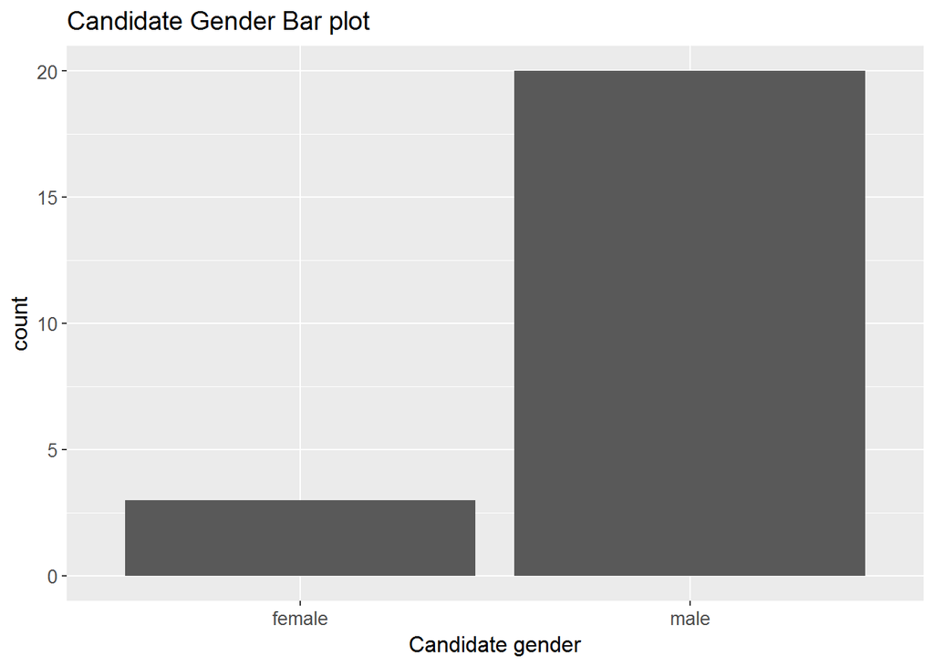

```
##
## female   male
##      3     20
```

From this plot its clear the proportion of male candidates has been more than the female candidates in the presidential elections with 3 female candidates v/s 20 male candidates

```
##
##   Democratic        Green Independents  Libertarian   Republican
##            5            1            1            1           17
```

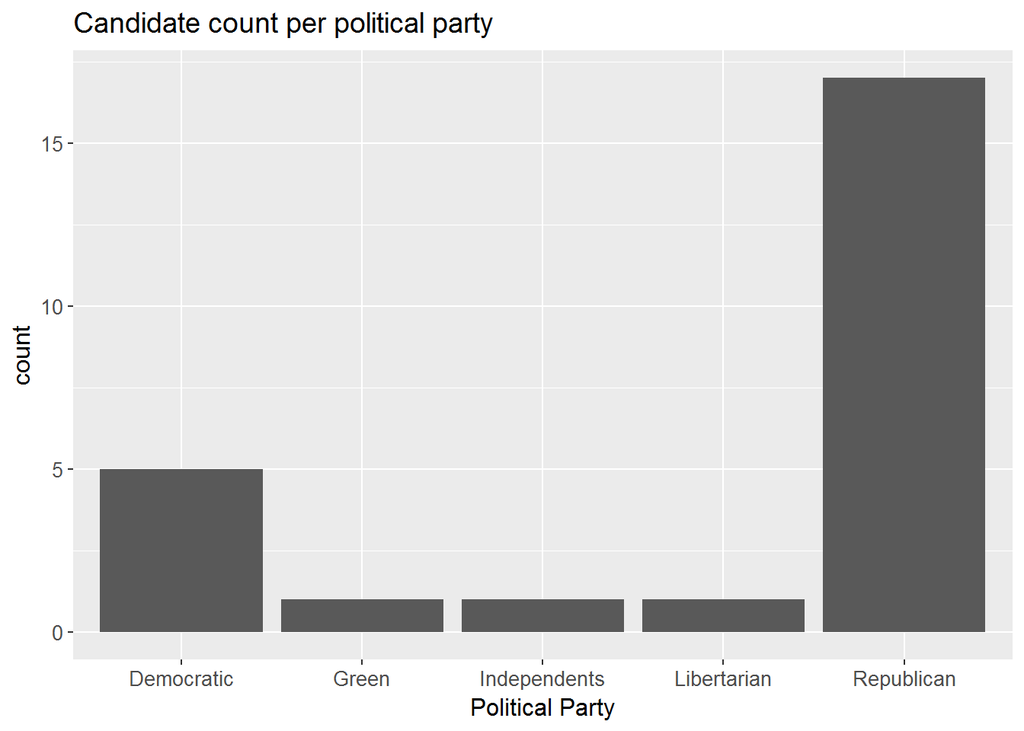

From this plot its clear that the number of candidates contesting the presidential election with the maximum being for Republican party with count of 17 followed by Democratic having count of 5

I wanted to analyze the contributions made per political party

```
## # A tibble: 5 × 2
##          party   count
##          <chr>   <int>
## 1   Democratic 1096563
## 2        Green    2842
## 3 Independents     306
## 4  Libertarian    1758
## 5   Republican  202877
```

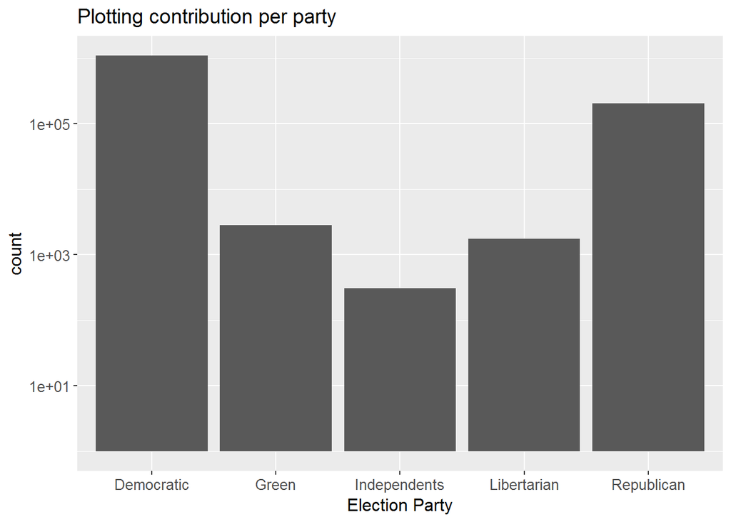

On analyzing the dataset, I found large number of negative contribution amounts for the contributors which on digging further I found were refunds when the candidate drops out of the race. So I summed the contribution amount based on the contributor details and the candidate for whom contribution has been made.There are still some negative values present which might mean that some data is missing due to which the contribution amounts have not been cancelled out in the cleaned data set.

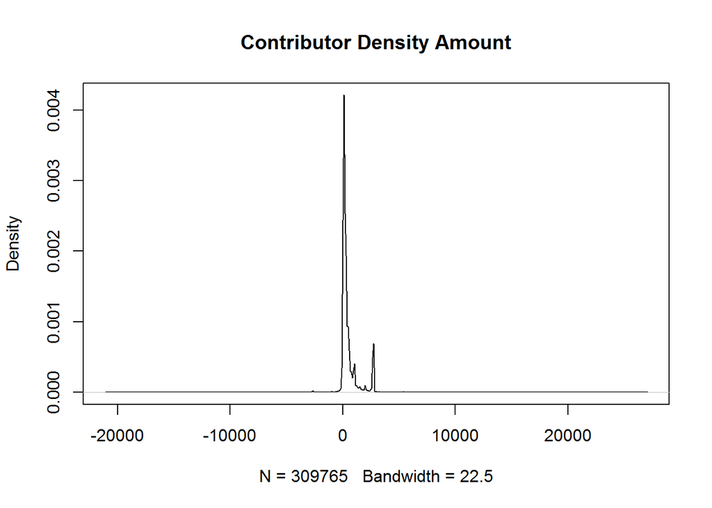

```
##     Min.  1st Qu.   Median     Mean  3rd Qu.     Max.
## -21050.0     80.0    200.0    489.4    500.0  27000.0
```

The above contributor density plot still shows lot of negative contribution amount, which for the purpose of this investigation should be ignored.

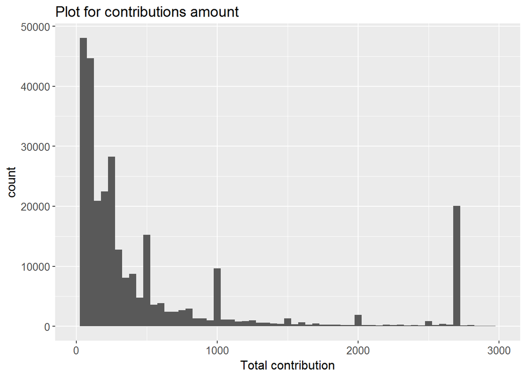

I transformed the total contribution visualization to get a better understanding of the plot by re- arranging the axis from 0 to 3000 since maximum contribution appear in the range of 0-3000$. The plot is positively skewed with an outlier at around 2800$. The maximum contribution appears in the range 0-500$.

```
## # A tibble: 10 × 2
##        contbr_occupation  count
##                   <fctr>  <int>
## 1                RETIRED 260546
## 2           NOT EMPLOYED 115598
## 3               ATTORNEY  36640
## 4  INFORMATION REQUESTED  30948
## 5                TEACHER  29104
## 6               ENGINEER  17749
## 7              HOMEMAKER  17268
## 8              PHYSICIAN  16111
## 9      SOFTWARE ENGINEER  15156
## 10             PROFESSOR  14949
```

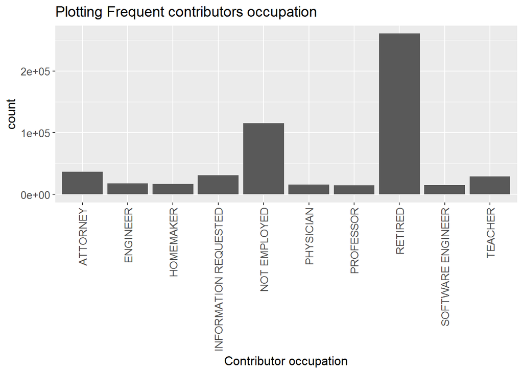

I wanted to determine the overall occupation of contributors who contributed in the presidential elections. So the Bar plot above represents the top 10 contributor’s occupation with the top most being Retired having count of 260546.

```
## # A tibble: 10 × 2
##          contbr_employer  count
##                   <fctr>  <int>
## 1                     NA 195904
## 2                RETIRED 121569
## 3          SELF-EMPLOYED 120187
## 4                   NONE  84297
## 5           NOT EMPLOYED  50821
## 6          SELF EMPLOYED  38881
## 7                   SELF  36395
## 8  INFORMATION REQUESTED  30412
## 9    STATE OF CALIFORNIA   5884
## 10                GOOGLE   5002
```

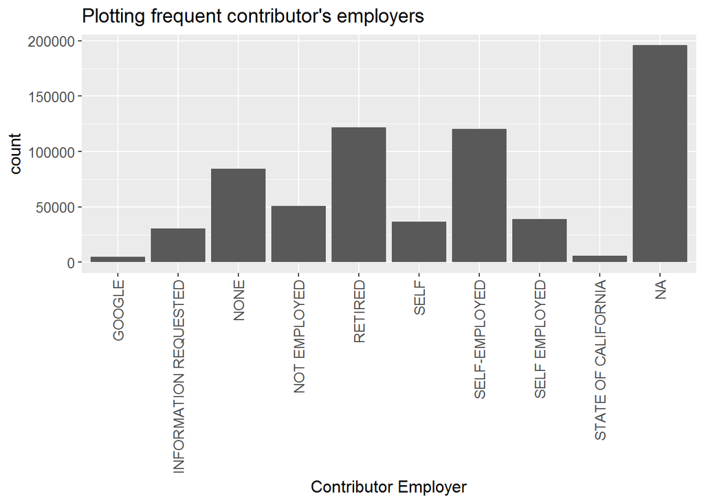

Also I want to determine who were the employers whose employees participated in the contribution. From this bar plot it shows that contributors having blank employement information have the highest count of contribution followed by the retired employees in this dataset. The reason for this blank employee information I could think of could be because of either missing data/employee’s didn’t want to disclose their employer at the time of filing these contributions or probably they didn’t have any employer!!

Similarly I want to determine the year with the maximum contributions made by the contributors.

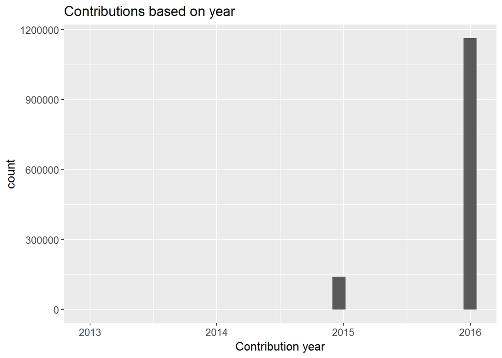

```
##
##    2013    2014    2015    2016
##       2     135  140645 1163564
```

This shows that the maximum contribution from years 2013-2016 has been in year 2016. And though this data is for 2016 presidential election, there are some insignificant count of contributions made in the year 2013-2014 which have been identified while plotting this visualization.

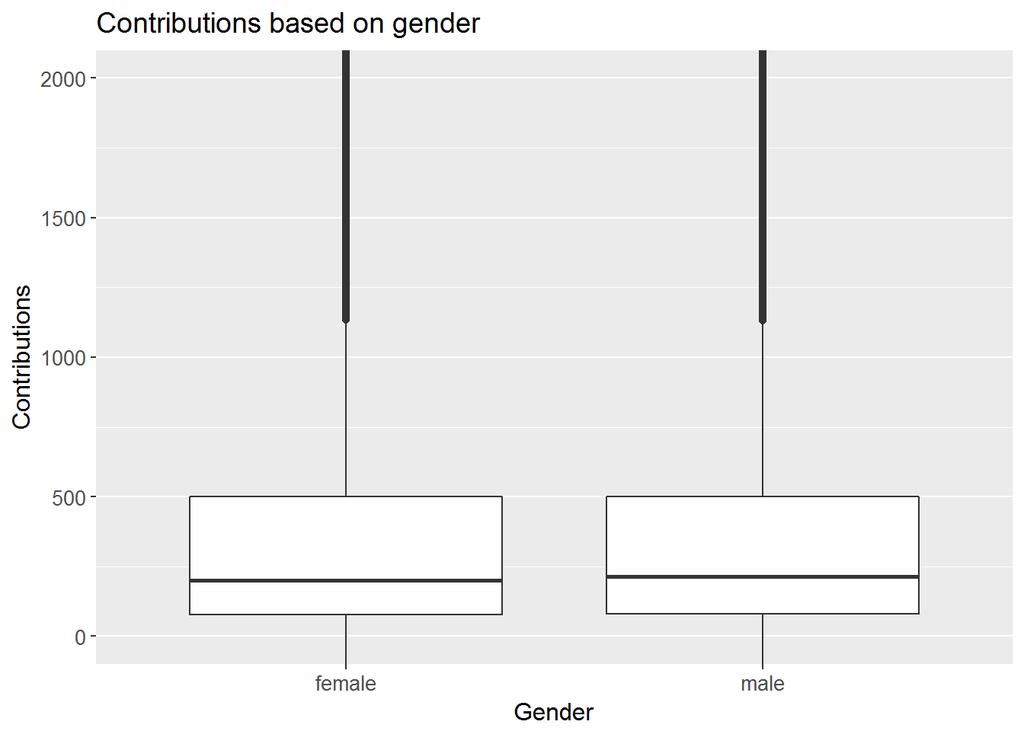

```
## ca_contrib_amt$contributor_gender: female
##     Min.  1st Qu.   Median     Mean  3rd Qu.     Max.
## -21050.0     78.0    200.0    464.3    500.0  21250.0
## --------------------------------------------------------
## ca_contrib_amt$contributor_gender: male
##     Min.  1st Qu.   Median     Mean  3rd Qu.     Max.
## -14180.0     80.0    215.0    510.2    500.0  27000.0
```

This plot above shows the contribution made on the basis of gender by male/female contributors. I chose to ignore the negative contributions as well as the contributors whose gender could not de determined from gender package. So I set the range of this boxplot to 0-2000 dollars. This boxplot shows that for female contributors 25 percent contributed less than 78 dollars and for male contributors this amount is 80 dollars. The median for female and male contributors had been 200 dollars and 215 dollars respectively.25% of female and male contributors contributed more than 500 dollars and with the maximum being 21250 dollars for females and 27000 dollars for males.

# Univariate Analysis

### What is/are the main feature(s) of interest in your dataset?

The main feature that interests me in this dataset are the contribution amount and the candidate for whom this contribution has been made.I’d like to examine whatfeatures influences contributors to contribute to a political party. Probably the contributor has some affiliations to a political party or maybe some other variable combinations can be used to determine a predictive model.

### What other features in the dataset do you think will help support your investigation into your feature(s) of interest?

The candidate’s political party, candidate name, election type, candidate’s gender, contributor’s gender are some of the factors I could think of which might influence a contributor to contribute for a particular candidate. On the basis of my current analysis, I think political party plays a definitive role in the contribution.

### Did you create any new variables from existing variables in the dataset?

Yes, I added a couple of variables in the dataset which would help me further in my analysis. These variables were  
* first_name and last_name: first and last name of candidate  
* candidate_gender : gender of candidate  
* party: political party of the candidate  
* election_type: identified type of election from abbreviated election_type like Primary, General etc.  
* contrib_year: Contribtion year extracted from contribution date  
* contrib_month: contribution month extracted from contribution date

### Of the features you investigated, were there any unusual distributions? Did you perform any operations on the data to tidy, adjust, or change the form of the data? If so, why did you do this?

While analyzing thecontribution amounts, I found large number of negative contribution amounts which were basically refunds made to the contributors. Since having negative contributions are not valid contributions.So to tidy this dataset, I summed the total contributions contribution amount based on contributor details and candidate contributed to in a variable called total_contrib in another dataset and plotted visualizations based on the same. Also large number of columns had blank values associated with them, considering which could lead to incorrect analysis, so I replaced these blank values with “N/A”

# Bivariate Plots Section

# Bivariate Analysis

### Talk about some of the relationships you observed in this part of the investigation. How did the feature(s) of interest vary with other features in the dataset?

### Did you observe any interesting relationships between the other features (not the main feature(s) of interest)?

### What was the strongest relationship you found?

# Multivariate Plots Section

# Multivariate Analysis

### Talk about some of the relationships you observed in this part of the investigation. Were there features that strengthened each other in terms of looking at your feature(s) of interest?

### Were there any interesting or surprising interactions between features?

### OPTIONAL: Did you create any models with your dataset? Discuss the strengths and limitations of your model.

# Final Plots and Summary

# Reflection